# Problem Set #4 STATS 506

Author

Jun Su

**GitHub Repository:** [Homework 4 Repository](https://github.com/sujun-cmd/stats506-ps04)

## Q1. Tidyverse: New Zealand

### Q1A. Vote Counts by Year and Type

Generate a table of total votes across parties for each year and vote type, sorted by vote count.

```r
library(dplyr)
nzge <- readRDS("data/nzge.rds")

nzge %>%
  select(voting_type, election_year, votes) %>%
  group_by(election_year, voting_type) %>%
  summarise(total_votes = sum(votes), .groups = "drop") %>%
  arrange(desc(total_votes))
```

```
# A tibble: 10 × 3
   election_year voting_type total_votes
           <dbl> <chr>             <dbl>
 1          2014 Party           2416479
 2          2014 Candidate       2375493
 3          2008 Party           2356536
 4          2008 Candidate       2325598
 5          2005 Party           2286190
 6          2005 Candidate       2260670
 7          2011 Party           2257336
 8          2011 Candidate       2225766
 9          2002 Party           2040248
10          2002 Candidate       2022115
```

### Q1B. Candidate Vote Proportions in 2014

Report each party’s proportion of Candidate votes in the 2014 election. Present a table sorted by percentage of votes.

```r
nzge %>%
  filter(election_year == 2014 & voting_type == "Candidate") %>%
  group_by(party) %>%
  summarise(total_votes = sum(votes), .groups = "drop") %>%
  mutate(percentage = total_votes / sum(total_votes) * 100) %>%
  arrange(desc(percentage))
```

```
# A tibble: 25 × 3
   party                    total_votes percentage
   <chr>                          <dbl>      <dbl>
 1 National Party               1081787     45.5
 2 Labour Party                  801287     33.7
 3 Green Party                   165718      6.98
 4 Conservative Party             81075      3.41
 5 New Zealand First Party        73384      3.09
 6 Maori Party                    42108      1.77
 7 MANA Movement                  32333      1.36
 8 Informal Candidate Votes       27886      1.17
 9 ACT New Zealand                27778      1.17
10 United Future                  14722      0.620
# ℹ 15 more rows
```

### Q1C. Winning Parties by Year

Produce a table identifying the party that won the Candidate vote and the party that won the Party vote in each year.

```r
nzge %>%
  group_by(election_year, voting_type, party) %>%
  summarise(total_votes = sum(votes), .groups = "drop") %>%
  group_by(election_year, voting_type) %>%
  slice_max(total_votes, n = 1, with_ties = TRUE) %>%
  ungroup() %>%
  arrange(desc(total_votes))
```

```
# A tibble: 10 × 4
   election_year voting_type party          total_votes
           <dbl> <chr>       <chr>                <dbl>
 1          2014 Party       National Party     1131501
 2          2014 Candidate   National Party     1081787
 3          2008 Candidate   National Party     1072024
 4          2011 Party       National Party     1058636
 5          2008 Party       National Party     1053398
 6          2011 Candidate   National Party     1027696
 7          2005 Party       Labour Party        935319
 8          2005 Candidate   National Party      902874
 9          2002 Candidate   Labour Party        891866
10          2002 Party       Labour Party        838219
```

## Q2. Tidyverse: Tennis

### Q2A. Number of Tournaments

How many tournaments took place in 2019?

```r
library(readr)
library(dplyr)

tennis <- read_csv("data/atp_matches_2019.csv")
tennis %>%
  group_by(tourney_id) %>%
  summarise(n_matches = n(), .groups = "drop") %>%
  summarise(n_tournaments = n())
```

```
# A tibble: 1 × 1
  n_tournaments
          <int>
1           128
```

There are 128 tournaments in 2019. ### Q2B. Players with Multiple Tournament Wins

Did any player win more than one tournament? If so, how many players did so, and how many tournaments did the most winning player(s) win?

```r
tournament_wins <- tennis %>%
  filter(round == "F") %>%
  group_by(winner_id, winner_name) %>%
  summarise(
    n_tournaments = n_distinct(tourney_id),
    .groups = "drop"
  ) %>%
  filter(n_tournaments > 1) %>%
  arrange(desc(n_tournaments))
tournament_wins$n_tournaments[1]
```

```
[1] 5
```

```r
length(tournament_wins$winner_id)
```

```
[1] 12
```

12 players win more than one tournament, the most winning player(s) won 5. ### Q2C. Aces for Winners and Losers

Is there evidence that winners have more aces than losers? If using a hypothesis test, remain within the tidyverse rather than using base R testing functionality.

# H0: mean difference = 0

# H1: mean difference > 0

```r
library(tidyr)
library(infer)
ace_data <- tennis %>%
  select(w_ace, l_ace) %>%
  drop_na(w_ace, l_ace) %>%
  mutate(ace_diff = w_ace - l_ace)


ace_data %>%
  summarise(
    n_matches = n(),
    mean_winner_aces = mean(w_ace),
    mean_loser_aces = mean(l_ace),
    mean_difference = mean(ace_diff)
  )
```

```
# A tibble: 1 × 4
  n_matches mean_winner_aces mean_loser_aces mean_difference
      <int>            <dbl>           <dbl>           <dbl>
1      2694             7.50            5.79            1.70
```

```r
ace_data %>%
  t_test(
    response = ace_diff,
    mu = 0,
    alternative = "greater"
  )
```

```
# A tibble: 1 × 7
  statistic  t_df  p_value alternative estimate lower_ci upper_ci
      <dbl> <dbl>    <dbl> <chr>          <dbl>    <dbl>    <dbl>
1      12.4  2693 1.53e-34 greater         1.70     1.48      Inf
```

p value = 1.530201e-34<0.05, reject H0, there’s statistical evidence that winners have more aces than losers ### Q2D. Highest Win Rate

Identify the player(s) with the highest win rate among those who played at least five matches.

```r
wins <- tennis %>%
  group_by(player_id = winner_id, player_name = winner_name) %>%
  summarise(won_games = n(), .groups = "drop")

losses <- tennis %>%
  group_by(player_id = loser_id) %>%
  summarise(lost_games = n(), .groups = "drop")

wins %>%
  full_join(losses, by = "player_id") %>%
  mutate(
    won_games = replace_na(won_games, 0L),
    lost_games = replace_na(lost_games, 0L),
    all_games_played = won_games + lost_games
  ) %>%
  filter(all_games_played >= 5) %>%
  mutate(win_rate = won_games / all_games_played) %>%
  slice_max(win_rate, n = 1, with_ties = TRUE)
```

```
# A tibble: 1 × 6
  player_id player_name  won_games lost_games all_games_played win_rate
      <dbl> <chr>            <int>      <int>            <int>    <dbl>
1    104745 Rafael Nadal        60          9               69    0.870
```

The player with highest win rate is Rafael Nadal whose rate is 0.8695652. ## Q3. Visualization

### Q3A. Major and Minor Spikes

How many major and minor spikes in cases were there?

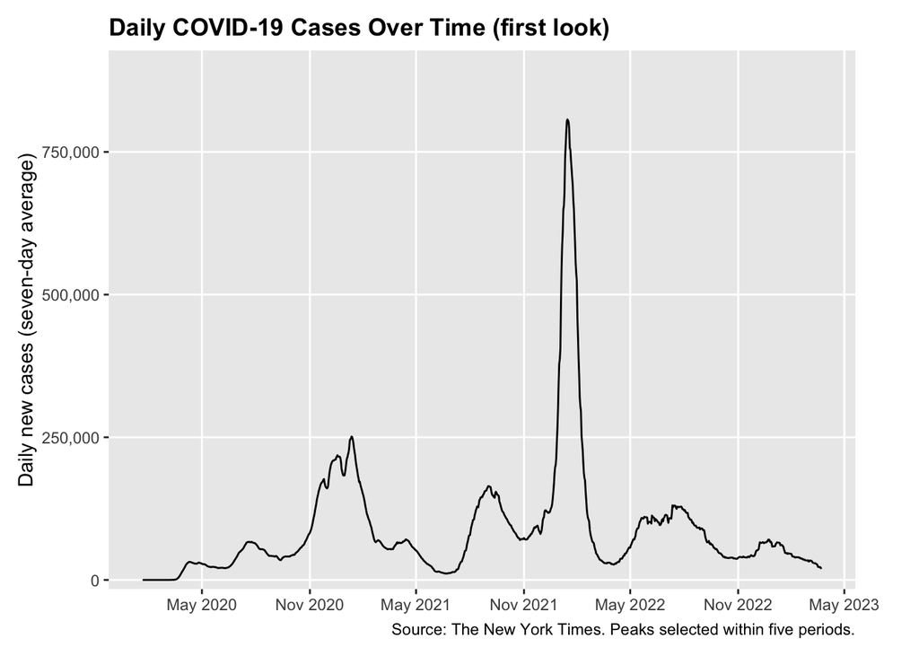

```r
library(ggplot2)
covid <- read_csv("data/us-states.csv")
daily_cases <- covid %>%
  group_by(date) %>%
  summarise(
    cases_avg = sum(cases_avg, na.rm = TRUE),
    .groups = "drop"
  )
# Find the spikes within the 5 observed peak periods
ggplot(daily_cases, aes(date, cases_avg)) +
  geom_line() +

  scale_x_date(date_breaks = "6 months", date_labels = "%b %Y") +
  scale_y_continuous(
    labels = scales::label_comma(),
    expand = expansion(mult = c(0.02, 0.15))
  ) +
  labs(
    title = "Daily COVID-19 Cases Over Time (first look)",
    x = NULL,
    y = "Daily new cases (seven-day average)",
    caption = "Source: The New York Times. Peaks selected within five periods."
  ) +
  theme(
  panel.grid.minor = element_blank(),
  plot.title = element_text(face = "bold"),
  plot.margin = margin(t = 10, r = 35, b = 10, l = 10)
)
```

We can see that these are 2 main peaks and 3 smaller peaks. Then, we will need to label these peaks.

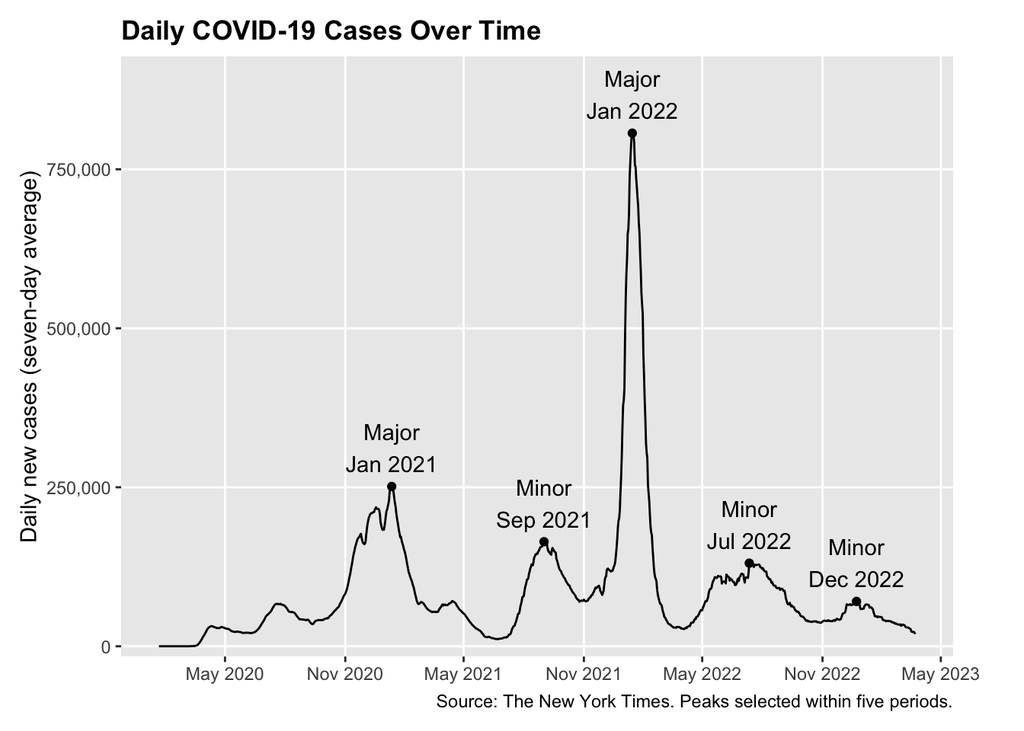

```r
peaks <- daily_cases %>%
  mutate(period = case_when(
    date >= "2020-11-01" & date <= "2021-02-28" ~ 1,
    date >= "2021-07-01" & date <= "2021-10-31" ~ 2,
    date >= "2021-12-01" & date <= "2022-02-28" ~ 3,
    date >= "2022-06-01" & date <= "2022-09-30" ~ 4,
    date >= "2022-12-01" & date <= "2023-02-28" ~ 5
  )) %>%
  filter(!is.na(period)) %>%
  group_by(period) %>%
  slice_max(cases_avg, n = 1, with_ties = FALSE) %>%
  ungroup() %>%
  mutate(label = paste(
    ifelse(period %in% c(1, 3), "Major", "Minor"),
    format(date, "%b %Y"),
    sep = "\n"
  ))

# Plot the peaks

ggplot(daily_cases, aes(date, cases_avg)) +
  geom_line() +
  geom_point(data = peaks) +
  geom_text(data = peaks, aes(label = label),vjust = -0.3) +
  scale_x_date(date_breaks = "6 months", date_labels = "%b %Y") +
  scale_y_continuous(
    labels = scales::label_comma(),
    expand = expansion(mult = c(0.02, 0.15))
  ) +
  labs(
    title = "Daily COVID-19 Cases Over Time",
    x = NULL,
    y = "Daily new cases (seven-day average)",
    caption = "Source: The New York Times. Peaks selected within five periods."
  ) +
  theme(
  panel.grid.minor = element_blank(),
  plot.title = element_text(face = "bold"),
  plot.margin = margin(t = 10, r = 35, b = 10, l = 10)
)
```

I found two major spikes, one in Jan 2022, the other in Jan 2021. I also observed 3 relatively prominent minor peaks, with smaller fluctuations occurring earlier in the series. I treated small fluctuations (especially these early stages in 2020) within the same overall rise-and-fall cycle as part of a single peak rather than counting them separately.

### Q3B. Highest and Lowest Rates per Population

For the states with the highest and lowest overall rates per population, what differences appear in their trajectories over time?

```r
# Calculate the avg cases_avg_per_100k rate for each state during the whole COVID period
state_rates <- covid %>%
  filter(state %in% state.name) %>%
  group_by(state) %>%
  summarise(
    mean_rate = mean(cases_avg_per_100k, na.rm = TRUE),
    .groups = "drop"
  )

# Select states with the highest and lowest rates
selected_states <- bind_rows(
  state_rates %>%
    slice_max(mean_rate, n = 1) %>%
    mutate(rate_group = "Highest"),
  state_rates %>%
    slice_min(mean_rate, n = 1) %>%
    mutate(rate_group = "Lowest")
)

selected_states
```

```
# A tibble: 2 × 3
  state        mean_rate rate_group
  <chr>            <dbl> <chr>
1 Rhode Island      38.7 Highest
2 Maryland          19.8 Lowest
```

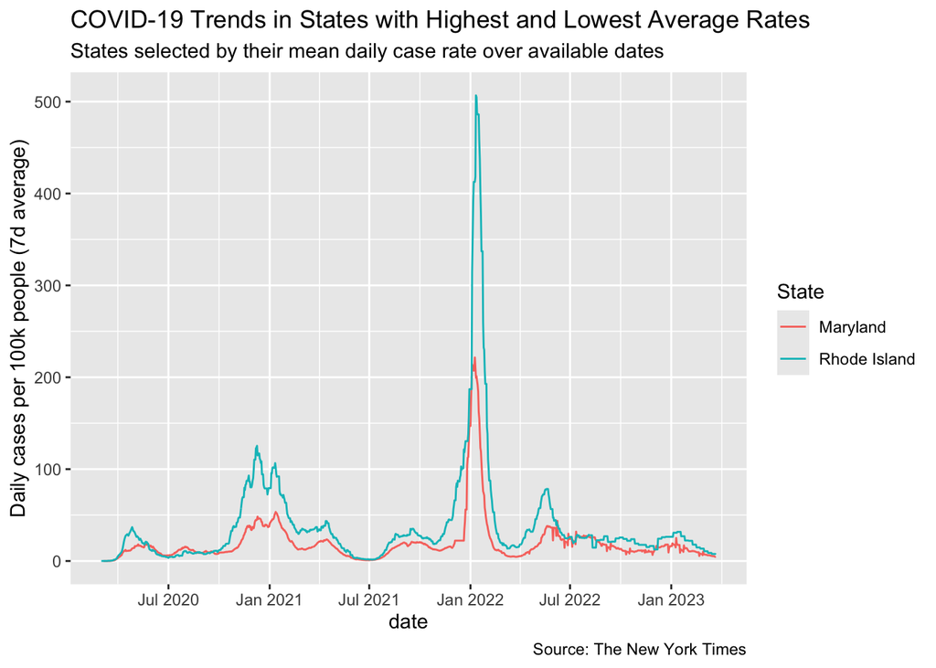

```r
# Plot their trajectories over time
covid %>%
  inner_join(selected_states, by = "state") %>%
  ggplot(aes(
    x = date,
    y = cases_avg_per_100k,
    color = state
  )) +
  geom_line() +
  scale_x_date(
    date_breaks = "6 months",
    date_labels = "%b %Y"
  ) +
  labs(
    title = "COVID-19 Trends in States with Highest and Lowest Average Rates",
    subtitle = "States selected by their mean daily case rate over available dates",
    y = "Daily cases per 100k people (7d average)",
    color = "State",
    caption = "Source: The New York Times"
  )
```

The highest is Rhode Island while the lowest is Maryland. Both states reached their highest peaks in January 2022, at nearly the same time. 1. Rhode Island had noticeably higher peaks in late 2020–early 2021 and January 2022. 2. The highest seven-day average of daily new cases per 100,000 people was approximately 507 in Rhode Island and 222 in Maryland, making Rhode Island’s peak about 2.3 times Maryland’s. 3. Both states saw sharp declines after their January 2022 peaks. Rhode Island also experienced a noticeable resurgence in the following spring.

### Q3C. First Five Substantially Affected States

Identify, to the best of your ability without a formal test, the first five states to experience Covid in a substantial way.

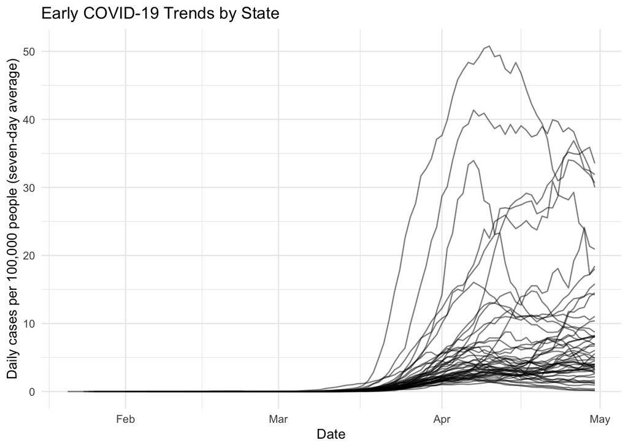

```r
# First, look at the early stages of COVID
covid %>%
  filter(
    date < as.Date("2020-05-01"),
    state %in% state.name
  ) %>%
  ggplot(aes(
    x = date,
    y = cases_avg_per_100k,
    group = state
  )) +
  geom_line(alpha = 0.5) +
  labs(
    title = "Early COVID-19 Trends by State",
    x = "Date",
    y = "Daily cases per 100,000 people (seven-day average)"
  ) +
  theme_minimal()
```

We found that the cases increased sharply since mid march. Take 5 as a threshold of experiencing Covid in a substantial way.

```r
first_reached <- covid %>%
  filter(
    state %in% state.name,
    cases_avg_per_100k >= 5
  ) %>%
  group_by(state) %>%
  summarise(
    first_date = min(date),
    .groups = "drop"
  ) %>%
  arrange(first_date)

first_five <- first_reached %>%
  slice_min(first_date, n = 5)

first_five
```

```
# A tibble: 6 × 2
  state         first_date
  <chr>         <date>
1 New York      2020-03-21
2 New Jersey    2020-03-24
3 Louisiana     2020-03-26
4 Massachusetts 2020-03-27
5 Connecticut   2020-03-28
6 Michigan      2020-03-28
```

New York, New Jersey, Louisiana, and Massachusetts were the first four states to reach the threshold for being substantially affected by COVID-19, with Connecticut and Michigan tied for fifth.

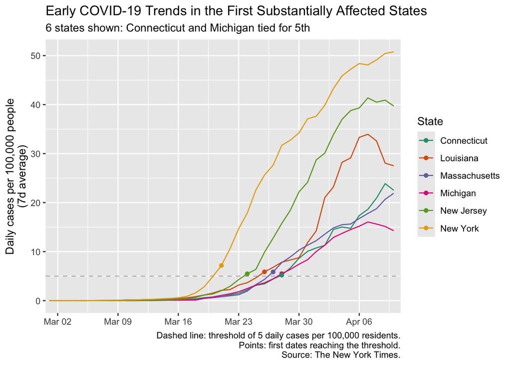

```r
first_points <- covid %>%
  inner_join(
    first_five,
    by = c("state", "date" = "first_date")
  )
covid %>%
  semi_join(first_five, by = "state") %>%
  filter(
    date >= as.Date("2020-03-01"),
    date <= as.Date("2020-04-10")
  ) %>%
  ggplot(aes(
    x = date,
    y = cases_avg_per_100k,
    color = state
  )) +
  geom_hline(
    yintercept = 5,
    linetype = "dashed",
    color = "gray"
  ) +
  geom_line() +
  geom_point(
    data = first_points,
  ) +

  scale_x_date(
    limits = as.Date(c("2020-03-01", "2020-04-10")),
    date_breaks = "1 week",
    date_labels = "%b %d",
    expand = expansion(mult = c(0.01, 0.02))
  ) +
  scale_color_brewer(palette = "Dark2") +
  labs(
    title = "Early COVID-19 Trends in the First Substantially Affected States",
    subtitle = "6 states shown: Connecticut and Michigan tied for 5th",
    x = NULL,
    y = "Daily cases per 100,000 people\n(7d average)",
    color = "State",
    caption = paste(
      "Dashed line: threshold of 5 daily cases per 100,000 residents.",
      "Points: first dates reaching the threshold.",
      "Source: The New York Times.",
      sep = "\n"
    )
  )
```

## Attribution of Sources

OpenAI ChatGPT was used to review my draft against the assignment requirements and to explain the help documents. I wrote, reviewed, and verified the final code myself.